# WES in nivolumab-treated melanoma: a reanalysis of Riaz et al. (2017)

Kwaku Darkwah (WES lead) · Group: Krithika (TCR), Ethan (RNA), Kwaku (WES)

November 06, 2026

**Analysis by:** Kwaku Darkwah (whole exome sequencing). **Source:** Riaz et al., *Cell* 2017, [DOI 10.1016/j.cell.2017.09.028](https://doi.org/10.1016/j.cell.2017.09.028); code and processed data from riazn/bms038_analysis.

# Background

**Nivolumab** is an antibody that blocks PD-1, a brake on T cells. Tumors press that brake to hide from the immune system; releasing it lets T cells attack. It works in only some melanoma patients.

**Whole exome sequencing (WES)** reads the protein-coding 1–2% of the genome (the exome) at high depth. Sequencing the tumor and the patient’s normal blood separates mutations the cancer acquired (somatic) from inherited ones. From somatic mutations we get:

1. **Mutation burden:** the number of nonsynonymous (protein-changing) mutations.
2. **Neoantigens:** mutated peptides predicted to bind the patient’s HLA molecules, which T cells can recognise.
3. **Change on treatment:** comparing the biopsy before treatment with one taken about 4 weeks in.

**Question:** when nivolumab works, do tumors lose their mutations? Response groups are PR/CR (partial or complete response), SD (stable disease) and PD (progressive disease).

# Setup

Downloads the authors’ repository at the exact commit used here, extracts their `nrstats` helper package, and installs missing CRAN packages. This only runs the first time.

```r
commit <- '137111c38a32f8626ee6a436e14ac667bd31b1e7'
root <- normalizePath('.', winslash = '/')
ext <- file.path(root, 'external')
repo_dir <- file.path(ext, 'bms038_analysis')
dir.create(ext, showWarnings = FALSE)
if (!dir.exists(repo_dir)) {
  stopifnot(system2('git', c('clone', 'https://github.com/riazn/bms038_analysis.git', repo_dir)) == 0)
}
stopifnot(system2('git', c('-C', repo_dir, 'checkout', '--quiet', commit)) == 0)
# nrstats is only used for its survival plotting functions, so extract rather than install
if (!dir.exists(file.path(ext, 'nrstats'))) {
  untar(file.path(repo_dir, 'packages', 'nrstats_0.1.0.tar.gz'), exdir = ext)
}
pkgs <- c('ggplot2', 'survival', 'RColorBrewer', 'ks')
missing <- pkgs[!pkgs %in% rownames(installed.packages())]
if (length(missing)) install.packages(missing, repos = 'https://cloud.r-project.org')
```

```r
library(survival); library(ggplot2)
repo <- paste0(repo_dir, '/')
out <- paste0(root, '/wes/results/')
dir.create(paste0(out, 'original_figures'), showWarnings = FALSE, recursive = TRUE)
source(paste0(ext, '/nrstats/R/graphs_survival.r'))
env <- environment()

# Upstream code relies on merge() row order (e.g. df$col[idx] <- ...), so sort
# strings byte-wise, as SQLite does, on every platform.
invisible(Sys.setlocale('LC_COLLATE', 'C'))
# Plain-R stand-in for the two sqldf queries the upstream scripts run
# (select [Key,] COUNT(*) as Name from tbl group by Key). sqldf's compiled
# dependencies are blocked by Windows Smart App Control on some machines.
sqldf <- function(q) {
  m <- regmatches(q, regexec('(?i)select\\s+(?:(\\w+)\\s*,\\s*)?count\\(\\*\\)\\s+as\\s+(\\w+)\\s+from\\s+(\\w+)\\s+group\\s+by\\s+(\\w+)', q, perl = TRUE))[[1]]
  if (length(m) == 0) stop('Unsupported sqldf query: ', q)
  d <- get(m[4], envir = parent.frame())
  tab <- table(d[[m[5]]])
  res <- data.frame(as.vector(tab))
  names(res) <- m[3]
  if (nzchar(m[2])) res <- cbind(setNames(data.frame(names(tab), stringsAsFactors = FALSE), m[2]), res)
  res
}
stext <- function(text, pos = 0, side = 3, ...) mtext(text, side = side, line = pos, cex = .7)
# Compatibility replacement for old nrstats boxplot layout, preserving tests.
tTestandGraph <- function(dat, groupCol, groups, valCol, groupLabels, tit = '', ...) {
  d <- dat[dat[[groupCol]] %in% groups, , drop = FALSE]
  d$Group <- factor(d[[groupCol]], levels = groups, labels = groupLabels)
  a <- d[[valCol]][d$Group == groupLabels[1]]; b <- d[[valCol]][d$Group == groupLabels[2]]
  cap <- sprintf('Welch t-test p=%.3g; Wilcoxon p=%.3g', t.test(a, b)$p.value, wilcox.test(a, b)$p.value)
  ggplot(d, aes(Group, .data[[valCol]])) + geom_boxplot() + geom_point() + theme_bw() + labs(title = tit, caption = cap)
}
# Run an upstream script unchanged on disk: drop workspace clearing and package
# loads we replace above, point PARENTDIR at the local copy, raise PNG resolution.
run_original <- function(file) {
  lines <- readLines(paste0(repo, file))
  lines <- lines[!grepl('^rm\\(list|^library\\(nrstats\\)|^library\\(sqldf\\)', lines)]
  lines[grepl('^PARENTDIR <-', lines)] <- paste0('PARENTDIR <- "', repo, '"')
  lines <- gsub('png(', 'png(width=1800,height=1400,res=180, ', lines, fixed = TRUE)
  invisible(capture.output(eval(parse(text = lines), envir = env)))
}
save_plot <- function(p, name, w = 10, h = 6) {
  ggsave(paste0(out, name, '.png'), p, width = w, height = h, dpi = 300)
  ggsave(paste0(out, name, '.pdf'), p, width = w, height = h)
}
resp <- function(x) factor(x, levels = c('PRCR', 'SD', 'PD'), labels = c('PR/CR', 'SD', 'PD'))
```

# Run the authors’ exome scripts

These are the authors’ scripts, run unchanged apart from the in-memory adjustments above. Their original figures are copied to `wes/results/original_figures/`.

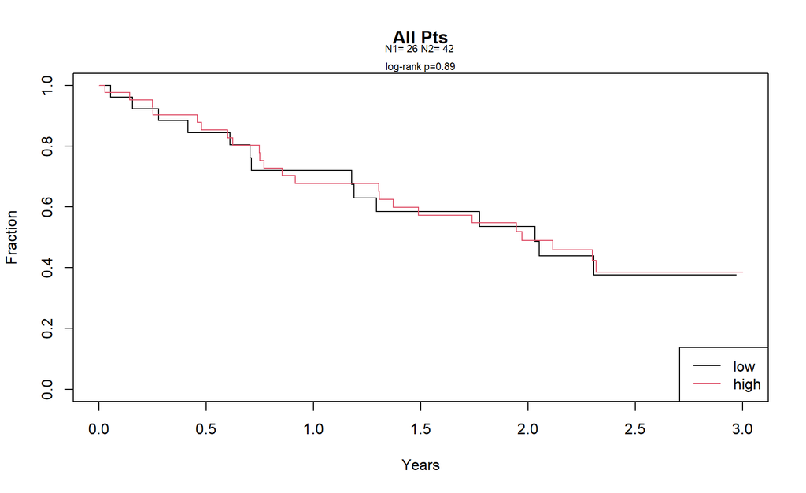

```r
setwd(repo)
run_original('exome/baseline_analysis.r')
```

```r
baseline <- ptdat
run_original('exome/baseline_clonality.r')
run_original('clonality_pre_post/clonality.analysis.R')
invisible(file.copy(list.files(paste0(repo, 'output'), pattern = '^(Fig1B|Fig2|SupFig1).*\\.(pdf|png)$', full.names = TRUE),
                    paste0(out, 'original_figures'), overwrite = TRUE))
setwd(root)
write.csv(baseline, paste0(out, 'baseline_patient_features.csv'), row.names = FALSE)
write.csv(combdat, paste0(out, 'baseline_clonality_features.csv'), row.names = FALSE)
```

# Result 1: baseline mutation burden

```r
baseline$Response <- resp(baseline$myBOR)
table(baseline$Response)
```

```
##
## PR/CR    SD    PD
##    15    23    30
```

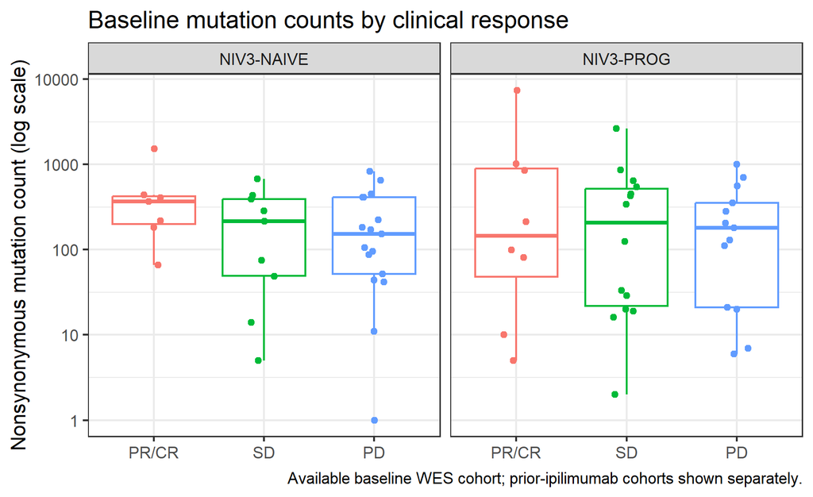

```r
p <- ggplot(baseline, aes(Response, NonSynMut, color = Response)) +
  geom_boxplot(outlier.shape = NA) + geom_point(position = position_jitter(width = .12, seed = 38), size = 2) +
  facet_wrap(~Cohort) + scale_y_log10() + theme_bw(base_size = 16) + theme(legend.position = 'none') +
  labs(title = 'Baseline mutation counts by clinical response', y = 'Nonsynonymous mutation count (log scale)', x = NULL,
       caption = 'Available baseline WES cohort; prior-ipilimumab cohorts shown separately.')
save_plot(p, '01_baseline_mutations_by_response')
p
```

# Result 2: mutations tracked between the two biopsies

Each mutation’s cancer cell fraction (the share of cancer cells carrying it, adjusted for tumor purity) is compared between biopsies. Using the authors’ categories at a 0.95 threshold, a mutation **contracts** (lost, or now in fewer cancer cells), **persists**, or **expands**.

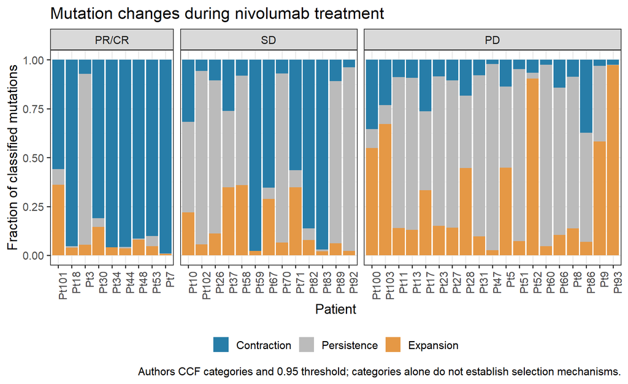

```r
changed <- update.ccf(dd, 'pyclone', .95, TRUE)
counts <- as.data.frame.matrix(table(changed$sample, changed$clonal2))
counts$Patient <- rownames(counts); counts$Response <- class[counts$Patient]
counts$Total <- rowSums(counts[, c('negative selection', 'no selection', 'positive selection')])
counts$Contraction_fraction <- counts[['negative selection']] / counts$Total
write.csv(counts, paste0(out, 'paired_mutation_features.csv'), row.names = FALSE)

long <- as.data.frame(table(changed$sample, changed$clonal2)); names(long) <- c('Patient', 'Category', 'Count')
long$Response <- resp(class[as.character(long$Patient)])
p <- ggplot(long, aes(Patient, Count, fill = Category)) + geom_col(position = 'fill') +
  facet_grid(~Response, scales = 'free_x', space = 'free_x') +
  scale_fill_manual(values = c('#277DA8', '#BBBBBB', '#E59845'), labels = c('Contraction', 'Persistence', 'Expansion')) +
  theme_bw(base_size = 14) + theme(axis.text.x = element_text(angle = 90, hjust = 1), legend.position = 'bottom') +
  labs(title = 'Mutation changes during nivolumab treatment', y = 'Fraction of classified mutations', x = 'Patient', fill = NULL,
       caption = 'Authors CCF categories and 0.95 threshold; categories alone do not establish selection mechanisms.')
save_plot(p, '02_mutation_changes_per_patient', 12, 6)
p
```

```r
counts$Response <- resp(counts$Response)
table(counts$Response)
```

```
##
## PR/CR    SD    PD
##     9    13    19
```

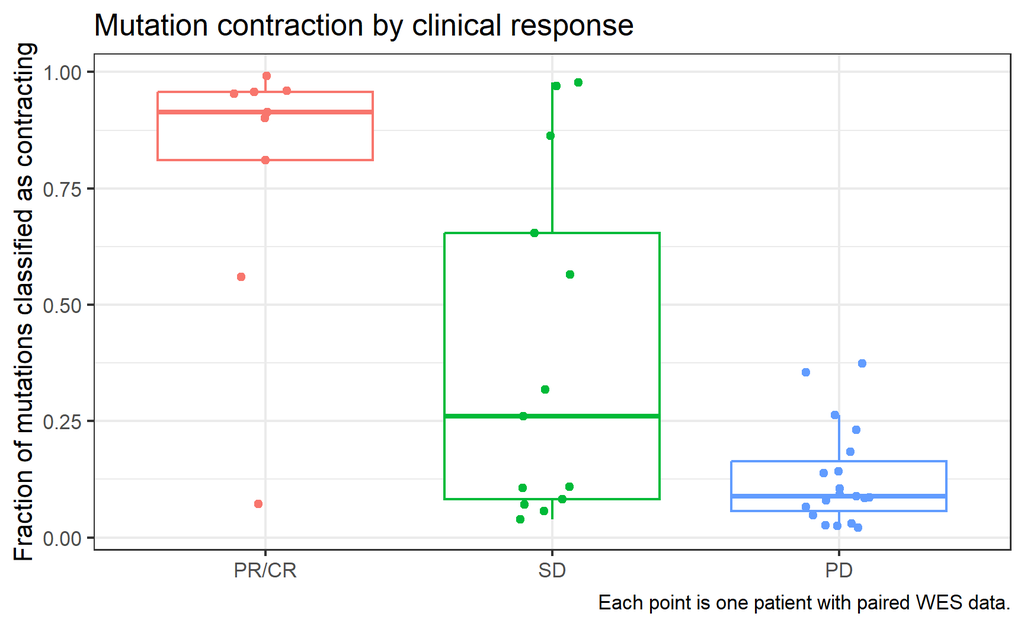

```r
p <- ggplot(counts, aes(Response, Contraction_fraction, color = Response)) +
  geom_boxplot(outlier.shape = NA) + geom_point(position = position_jitter(width = .12, seed = 38), size = 2) +
  theme_bw(base_size = 16) + theme(legend.position = 'none') +
  labs(title = 'Mutation contraction by clinical response', x = NULL, y = 'Fraction of mutations classified as contracting',
       caption = 'Each point is one patient with paired WES data.')
save_plot(p, '03_contraction_by_response')
p
```

# Result 3: neoantigens observed versus expected

Expected on-treatment neoantigens use silent mutations as the yardstick, since T cells cannot see them: `E_NeoAgCnt_On = SynMutCnt_On × NeoAgCnt_Pre / SynMutCnt_Pre`. A ratio below 1 means fewer neoantigens remain than if they had survived at the same rate as silent mutations.

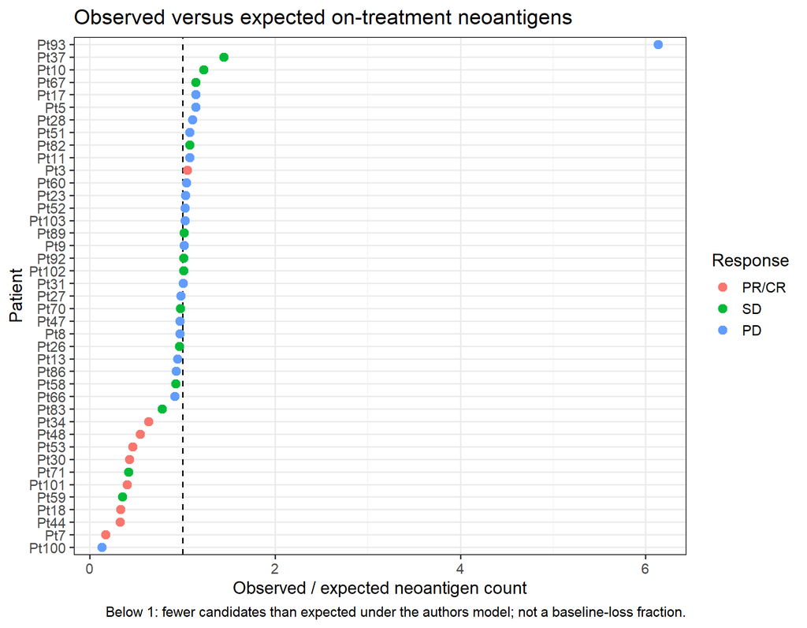

```r
neo <- read.csv(paste0(repo, 'neoantigen depletion/Mut_NeoAg_Expected_vs_Observed_BMS038.csv'))
stopifnot(all(neo$E_NeoAgCnt_On > 0))
neo$Observed_expected_ratio <- neo$NeoAgCnt_On / neo$E_NeoAgCnt_On
write.csv(neo, paste0(out, 'neoantigen_patient_features.csv'), row.names = FALSE)
# Authors' original plot, saved to PDF
setwd(paste0(repo, 'neoantigen depletion'))
pdf(paste0(out, 'original_figures/neoantigen_observed_expected.pdf'), width = 12, height = 7)
lines <- readLines('ObsvsExpt_NeoAg.R'); eval(parse(text = lines[!grepl('^rm\\(list', lines)])); invisible(dev.off())
setwd(root)

neo$Response <- resp(neo$myBOR)
p <- ggplot(neo, aes(reorder(Patient, Observed_expected_ratio), Observed_expected_ratio, color = Response)) +
  geom_hline(yintercept = 1, linetype = 2) + geom_point(size = 3) + coord_flip() + theme_bw(base_size = 14) +
  labs(title = 'Observed versus expected on-treatment neoantigens', x = 'Patient', y = 'Observed / expected neoantigen count',
       caption = 'Below 1: fewer candidates than expected under the authors model; not a baseline-loss fraction.')
save_plot(p, '04_neoantigen_observed_expected', 10, 8)
p
```

# Confidence intervals and tests

Percentile bootstrap 95% CIs for each group median and for the PR/CR − PD difference (10,000 resamples, seed 2017). Wilcoxon rank-sum tests compare PR/CR with PD only; these are exploratory, given the small groups.

```r
set.seed(2017)
B <- 10000
boot_med <- function(x) quantile(replicate(B, median(sample(x, replace = TRUE))), c(.025, .975))
boot_diff <- function(a, b) quantile(replicate(B, median(sample(a, replace = TRUE)) - median(sample(b, replace = TRUE))), c(.025, .975))
summarise <- function(val, grp, label) {
  rows <- lapply(c('PR/CR', 'SD', 'PD'), function(g) {
    x <- val[grp == g]; ci <- boot_med(x)
    data.frame(measure = label, group = g, n = length(x), median = median(x), lo = ci[1], hi = ci[2])
  })
  a <- val[grp == 'PR/CR']; b <- val[grp == 'PD']; ci <- boot_diff(a, b)
  rbind(do.call(rbind, rows),
        data.frame(measure = label, group = 'PR/CR minus PD', n = NA, median = median(a) - median(b), lo = ci[1], hi = ci[2]))
}
b <- baseline[!is.na(baseline$NonSynMut), ]
res <- rbind(summarise(b$NonSynMut, b$Response, 'baseline_nonsyn_mutations'),
             summarise(counts$Contraction_fraction, counts$Response, 'contraction_fraction'),
             summarise(neo$Observed_expected_ratio, neo$Response, 'neoantigen_obs_exp_ratio'))
rownames(res) <- NULL
write.csv(res, paste0(out, 'bootstrap_median_ci.csv'), row.names = FALSE)
knitr::kable(res, digits = 3)
```

| measure | group | n | median | lo | hi |
| --- | --- | --- | --- | --- | --- |
| baseline_nonsyn_mutations | PR/CR | 15 | 217.000 | 99.000 | 852.000 |
| baseline_nonsyn_mutations | SD | 23 | 214.000 | 29.000 | 428.000 |
| baseline_nonsyn_mutations | PD | 30 | 162.000 | 91.500 | 253.500 |
| baseline_nonsyn_mutations | PR/CR minus PD | NA | 55.000 | -94.500 | 393.025 |
| contraction_fraction | PR/CR | 9 | 0.914 | 0.560 | 0.960 |
| contraction_fraction | SD | 13 | 0.261 | 0.082 | 0.654 |
| contraction_fraction | PD | 19 | 0.088 | 0.066 | 0.142 |
| contraction_fraction | PR/CR minus PD | NA | 0.826 | 0.475 | 0.878 |
| neoantigen_obs_exp_ratio | PR/CR | 9 | 0.429 | 0.325 | 0.631 |
| neoantigen_obs_exp_ratio | SD | 13 | 1.010 | 0.926 | 1.077 |
| neoantigen_obs_exp_ratio | PD | 19 | 1.029 | 0.972 | 1.076 |
| neoantigen_obs_exp_ratio | PR/CR minus PD | NA | -0.600 | -0.704 | -0.401 |

```r
wil <- function(v, g) signif(wilcox.test(v[g == 'PR/CR'], v[g == 'PD'])$p.value, 3)
data.frame(measure = c('baseline_nonsyn_mutations', 'contraction_fraction', 'neoantigen_obs_exp_ratio'),
           wilcoxon_p_PRCR_vs_PD = c(wil(b$NonSynMut, b$Response), wil(counts$Contraction_fraction, counts$Response),
                                     wil(neo$Observed_expected_ratio, neo$Response)))
```

```
##                     measure wilcoxon_p_PRCR_vs_PD
## 1 baseline_nonsyn_mutations              0.236000
## 2      contraction_fraction              0.000104
## 3  neoantigen_obs_exp_ratio              0.000836
```

# Patients shared across WES, RNA and TCR

For the group’s integration: patients with all three data types at both timepoints.

```r
availability <- read.csv(paste0(repo, 'data/genomic_data_per_case.csv'))
shared <- availability[apply(availability[, -1], 1, function(x) all(!is.na(x) & x == 1)), ]
write.csv(shared, paste0(out, 'all_modality_paired_patient_ids.csv'), row.names = FALSE)
cat('Baseline WES:', nrow(baseline), ' Paired WES:', nrow(counts), ' Neoantigen:', nrow(neo), ' All three, both timepoints:', nrow(shared), '\n')
```

```
## Baseline WES: 68  Paired WES: 41  Neoantigen: 41  All three, both timepoints: 26
```

# Summary

- **Baseline burden is a weak predictor.** Median nonsynonymous mutations are similar across groups, and the PR/CR − PD difference has a confidence interval that crosses zero.
- **Responders lose most of their mutations.** The median share of mutations contracting is far higher in PR/CR than in PD.
- **Responders keep fewer neoantigens than expected.** Their observed/expected ratio sits well below 1, while progressors stay near 1. This fits T cells removing the cancer cells that display neoantigens.

# Limitations

- Reproduces the analysis from the authors’ processed data; mutations and neoantigens were not re-called from raw reads.
- “Contraction” includes mutations that went from clonal to subclonal, not only those that disappeared.
- More immune cells in an on-treatment biopsy can make mutations look lost. Cancer cell fractions adjust for purity, but low purity and read depth remain caveats.
- Groups are small, and the on-treatment biopsy is a single snapshot at about week 4.
- Figures use all patients with paired WES (41), not only the 26 shared across all three data types.